# Module 4

Patricia McGee

2/6/2022

## Module 4 Assignment

The assignment details are: Your assignment: The following data was collected by the local hospital. This data set contains 5 variables based on observation of 8 patients. In addition to the measurements of the patients checking in to the hospital that night, this data provides the patients’ histories regarding the frequency of their visits to the hospital in the last 12 months. This data displays the measurement of blood pressure, first assessment by general doctor (bad=1, good =0) titled “first,” the second assessment by external doctor (called “second”), and the last row provides the head of the emergency unit’s decision regarding immediate care for the patient based on the values 0 or 1 (low = 0, high =1). The names of your variables are as follows: “Freq”,“bloodp”,“first”, ” second”, ”finaldecision” The rows 1. “0.6”,“103”,“bad”,“low”,“low” 2. “0.3”,“87”,“bad”,“low”,“high” 3. “0.4”,“32”,“bad”,“high”,“low” 4. “0.4”,“42”,“bad”,“high”,“high” 5. “0.2”,“59”,“good”,“low”,“low” 6. “0.6”,“109”,“good”,“low”,“high” 7. “0.3”,“78”,“good”,“high”,“low” 8. “0.4”,“205”,“good”,“high”,“high” 9. “0.9”,“135”,”NA”,“high”,“high” 10. “0.2”,“176”,”bad”,“high”,“high” Here is Clarification hint: Frequency <- c(0.6,0.3,0.4,…… BP <- c(103,87,32,42,….. First <- c(1,1,1,….. Second <- c(0,0,1,1,… FinalDecision <- c(0,1,0,1,… Your first assignment: Create a side-by-side boxplot (boxplot(x, …)) and and histogram ((hist(x, …)). Discuss the outcome of your results regarding patients BPs & MD’s Ratings. Post your result in your blog and code on GitHub.

```r
Freq <- c(0.6,0.3,0.4,0.4,0.2,0.6,0.3,0.4,0.9,0.2)
BP <- c(103,87,32,42,59,109,78,205,135,176)
First <- c(1,1,1,1,0,0,0,0,NA,1)
Second <- c(0,0,1,1,0,0,1,1,1,1)
FinalDecision <- c(0,1,0,1,0,1,0,1,1,1)

patients <- data.frame(Freq,BP,First,Second,FinalDecision)
str(patients)
```

```
## 'data.frame':    10 obs. of  5 variables:
##  $ Freq         : num  0.6 0.3 0.4 0.4 0.2 0.6 0.3 0.4 0.9 0.2
##  $ BP           : num  103 87 32 42 59 109 78 205 135 176
##  $ First        : num  1 1 1 1 0 0 0 0 NA 1
##  $ Second       : num  0 0 1 1 0 0 1 1 1 1
##  $ FinalDecision: num  0 1 0 1 0 1 0 1 1 1
```

## Plots

Here we are creating a side by side boxplot and a histogram

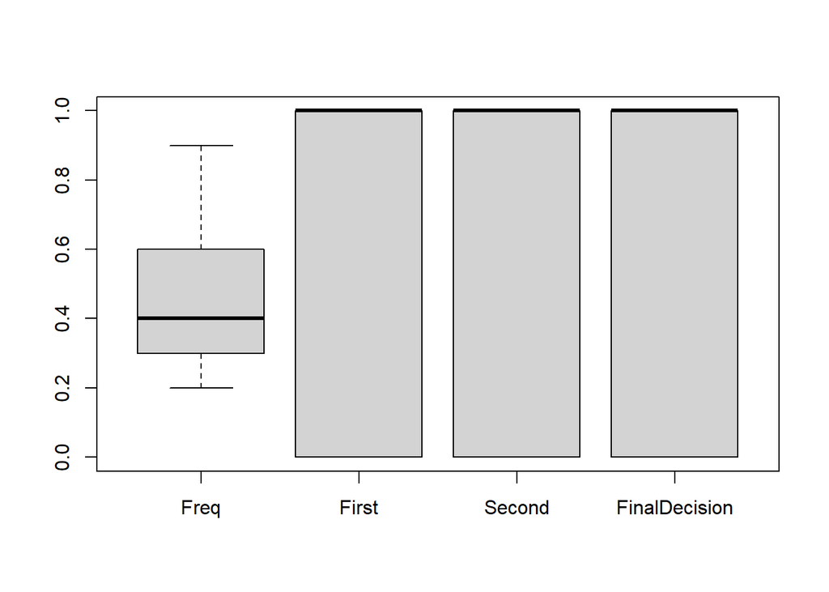

```r
boxplot(Freq, First, Second, FinalDecision, data = patients, names = c("Freq", "First", "Second", "FinalDecision"))
```

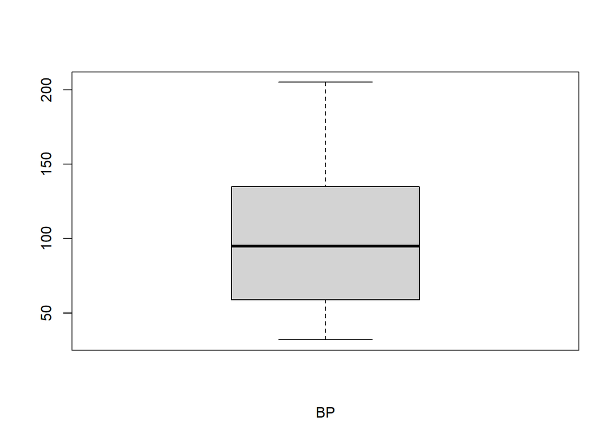

```r
#BP is on a different scale from the other values, so here that is as a separate boxplot
boxplot(BP, data = patients, xlab = "BP")
```

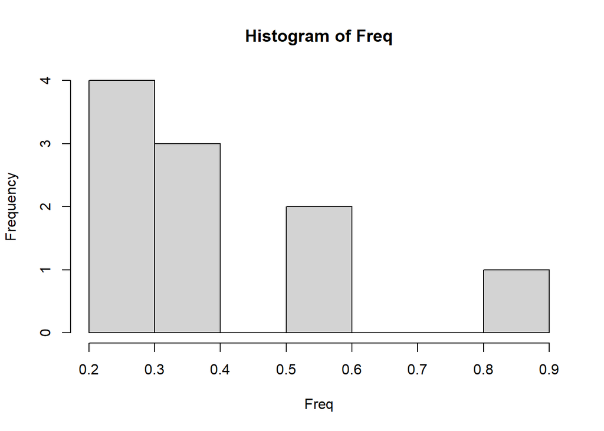

```r
hist(Freq, data = patients)
```

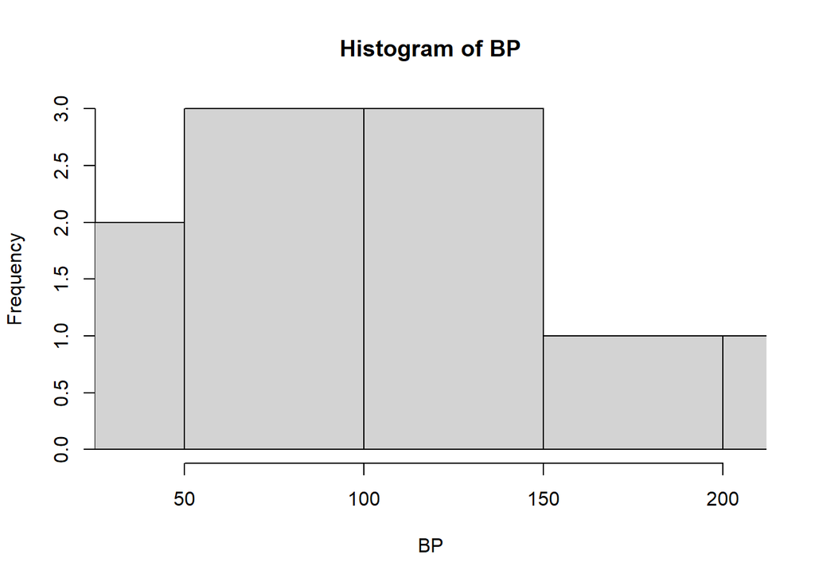

```r
hist(BP, data = patients, xlim = range(BP))
```

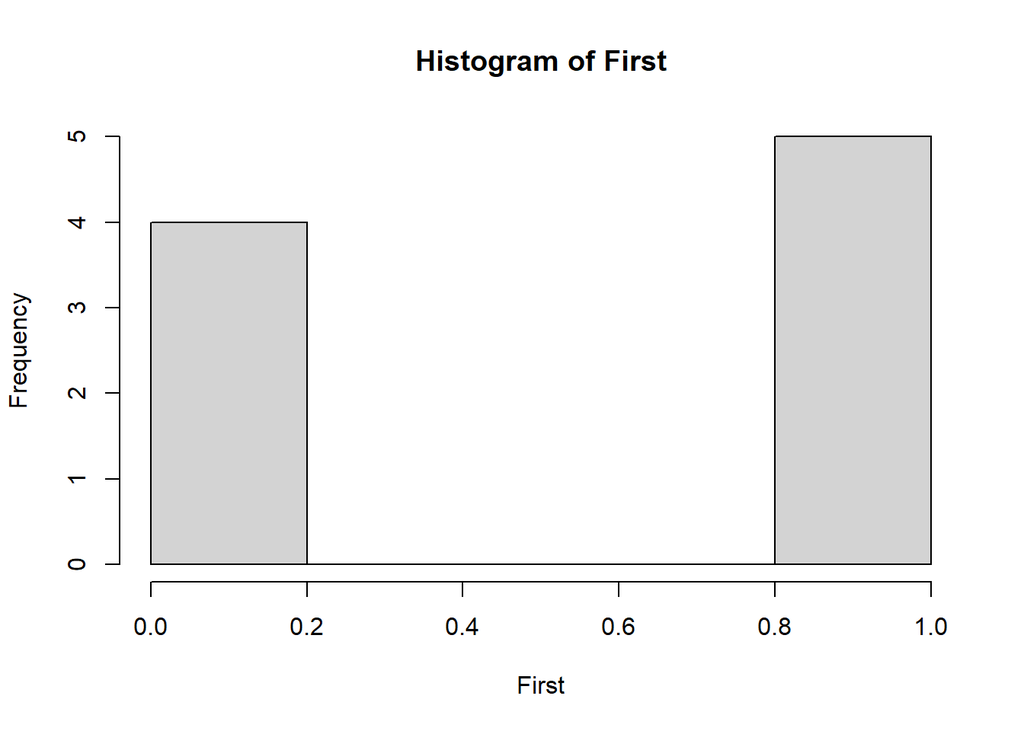

```r
hist(First, data = patients)
```

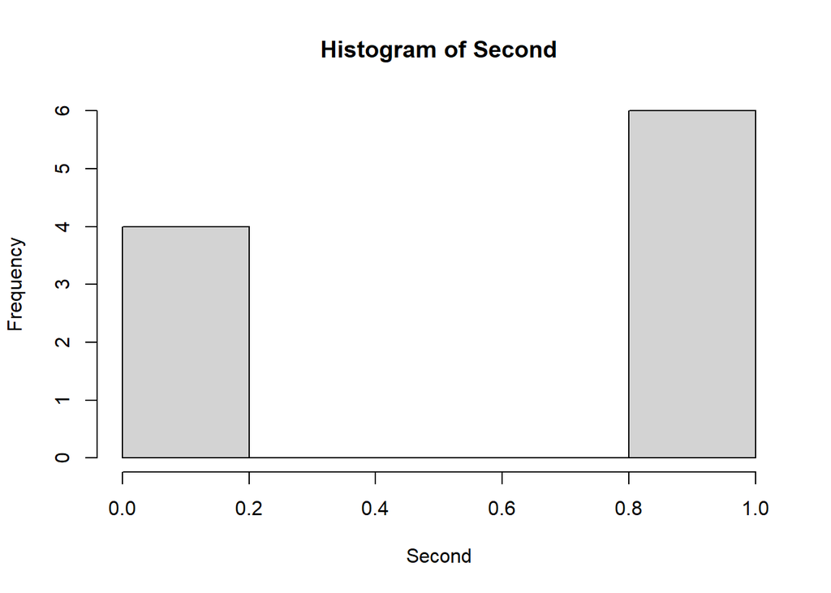

```r
hist(Second, data = patients)
```

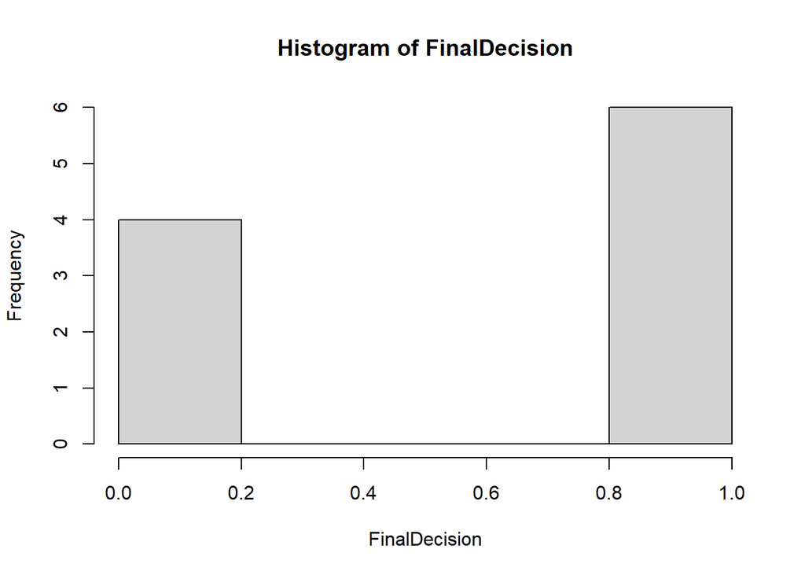

```r
hist(FinalDecision, data = patients)
```